# Power Analysis

- Main Vignette
- ABE
- RSABE
- Non-Inferiority
- Dose-Proportionality
- Power Analysis

### Details and examples of other methods are accessible via the menu bar on top of the page and in the [online manual](https://cran.r-project.org/package=PowerTOST/PowerTOST.pdf) of all functions.

```r
library(PowerTOST) # attach the library
```

# Defaults

Note that analysis of untransformed data (`logscale = FALSE`) is not supported. The terminology of the `design` argument follows this pattern: `treatments x sequences x periods`.

With `x <- pa.ABE(...)`, `x <- pa.scABE(...)`, and `x <- pa.NTID(...)` results are given as an S3 object,[^1] which can be printed, plotted, or both.

The estimated sample sizes give always the *total* number of subjects (not subject/sequence in crossovers or subjects/group in a parallel design – like in some other software packages).

## Function `pa.ABE()`

| Parameter | Argument | Purpose | Default |
| --- | --- | --- | --- |
| *CV* | `CV` | CV | none |
| $\small{\theta_0}$ | `theta0` | ‘True’ or assumed deviation of T from R | `0.95` |
| $\small{\pi}$ | `targetpower` | Minimum desired power | `0.80` |
| $\small{\pi}$ | `minpower` | Minimum acceptable power | `0.70` |
| design | `design` | Planned design | `"2x2x2"` |
| passed | `...` | Arguments to `power.TOST()` | none |

If no additional arguments are passed, the defaults of `power.TOST()` are applied, namely `alpha = 0.05`, `theta1 = 0.80`, `theta2 = 1.25`.

Arguments `targetpower`, `minpower`, `theta0`, `theta1`, `theta2`, and `CV` have to be given as fractions, not in percent.  
*CV* is generally the *within-* (intra-) subject coefficient of variation. In replicate designs only homoscedasticity (*CV*<sub>wT</sub> = *CV*<sub>wR</sub>) is supported. For `design = "parallel"` it is the *total* (a.k.a. pooled) *CV*.

The conventional TR|RT (a.k.a. AB|BA) design can be abbreviated as `"2x2"`. Some call the `"parallel"` design a ‘one-sequence’ design. The `"paired"` design has two periods but no sequences, *e.g.*, in studying linear pharmacokinetics a single dose is followed by multiple doses. A profile in steady state (T) is compared to the one after the single dose (R). Note that the underlying model assumes no period effects.

## Function `pa.scABE()`

[output not shown]

If no additional arguments are passed, the defaults of `power.scABEL()` and `power.RSABE()` are applied, namely `alpha = 0.05`, `theta1 = 0.80`, `theta2 = 1.25`. Note the recommended [^2] default $\small{\theta_0}$ 0.90 for HVDPs.  
`regulator` can be `"EMA"`, `"HC"`, `"GCC"`, or `"FDA"`.

Arguments `targetpower`, `minpower`, `theta0`, `theta1`, `theta2`, and `CV` have to be given as fractions, not in percent. *CV* is the *within-* (intra-) subject coefficient of variation, where only homoscedasticity (*CV*<sub>wT</sub> = *CV*<sub>wR</sub>) is supported.

[output not shown]

If no additional arguments are passed, the defaults of `power.NTID()` are applied, namely `alpha = 0.05`, `theta1 = 0.80`, `theta2 = 1.25`. Note the default $\small{\theta_0}$ 0.975 for NTIDs since the FDA requires tighter batch release limits of ±5% for them.

Arguments `targetpower`, `minpower`, `theta0`, `theta1`, `theta2`, and `CV` have to be given as fractions, not in percent. *CV* is the *within-* (intra-) subject coefficient of variation, where only homoscedasticity (*CV*<sub>wT</sub> = *CV*<sub>wR</sub>) is supported.

# Examples

## Average Bioequivalence

##### Example 1

Example 3 of vignette ABE. Assumed *CV* 0.20, $\small{\theta_0}$ 0.92.

```r
pa.ABE(CV = 0.20, theta0 = 0.92)
# Sample size plan ABE
#  Design alpha  CV theta0 theta1 theta2 Sample size Achieved power
#     2x2  0.05 0.2   0.92    0.8   1.25          28       0.822742
#
# Power analysis
# CV, theta0 and number of subjects leading to min. acceptable power of ~0.7:
#  CV= 0.2377, theta0= 0.9001
#  n = 21 (power= 0.7104)
```

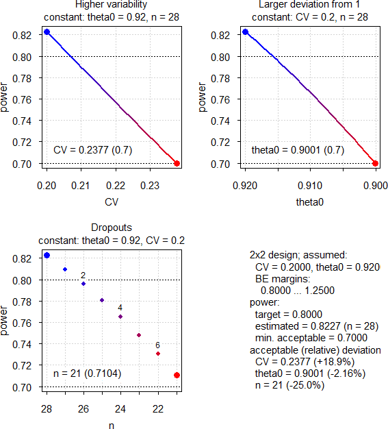

**Fig. 1** Power Analysis (in each panel one argument is varied and others kept constant)

The most critical parameter is $\small{\theta_0}$, whereas dropouts are the least important. We will see a similar pattern in other approaches as well.

## Reference-scaled Average Bioequivalence

### Highly Variable Drugs / Drug Products

#### EMA

##### Example 2

Assumed intra-subject *CV* 0.55.

```r
pa.scABE(CV = 0.55)
# Sample size plan scABE (EMA/ABEL)
#  Design alpha CVwT CVwR theta0 theta1 theta2 Sample size Achieved power
#   2x3x3  0.05 0.55 0.55    0.9    0.8   1.25          42        0.80848
#  Target power
#           0.8
#
# Power analysis
# CV, theta0 and number of subjects leading to min. acceptable power of ~0.7:
#  CV= 0.6668, theta0= 0.8689
#  n = 33 (power= 0.7085)
```

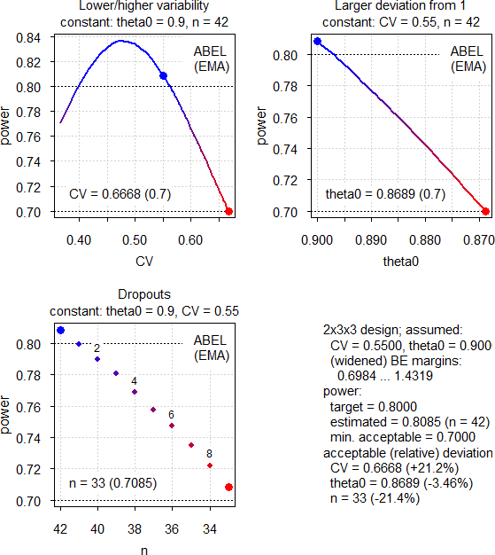

**Fig. 2** Power Analysis (in each panel one argument is varied and others kept constant)

The idea behind reference-scaling is to preserve power even for high variability without requiring extreme sample sizes. However, we make two interesting observations. At *CV*<sub>wR</sub> 0.55 already the upper cap of scaling (50%) cuts in and the expanded limits are the same as at *CV*<sub>wR</sub> 0.50. Therefore, if the variability increases, power decreases. On the other hand, if the CV decreases, power increases first (because being affected by the upper cap is less likely) and then decreases again (because the limits can be less expanded).

##### Example 3

Assumed intra-subject *CV* 0.40, 4-period full replicate design.

```r
pa.scABE(CV = 0.40, design = "2x2x4")
# Sample size plan scABE (EMA/ABEL)
#  Design alpha CVwT CVwR theta0 theta1 theta2 Sample size Achieved power
#   2x2x4  0.05  0.4  0.4    0.9    0.8   1.25          30        0.80656
#  Target power
#           0.8
#
# Power analysis
# CV, theta0 and number of subjects leading to min. acceptable power of ~0.7:
#  CV= 0.6938, theta0= 0.8763
#  n = 23 (power= 0.7123)
```

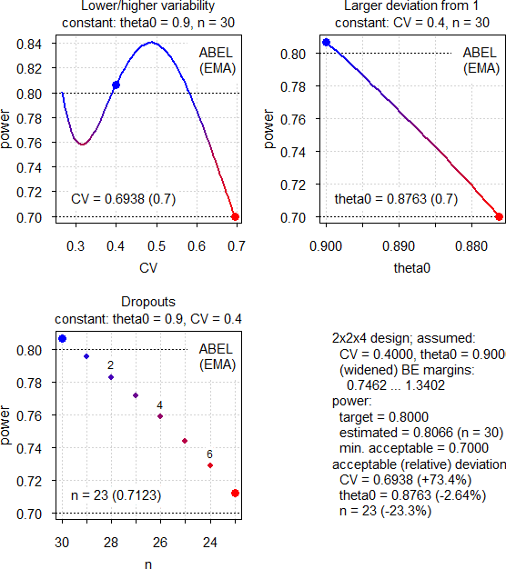

**Fig. 3** Power Analysis (in each panel one argument is varied and others kept constant)

Here we see a different pattern. With increasing variability power increases (due to more expanding) up to the cap of scaling where it starts to decrease like in the previous example. If the variability decreases, power decreases as well (less expanding). However, close the the switching *CV*<sub>wR</sub> (30%) power increases again. Although we cannot scale anymore, with 30 subjects the study is essentially ‘overpowered’ for ABE.

#### Health Canada

##### Example 4

Same assumptions (*CV*, $\small{\theta_0}$) like in Example 2.

```r
pa.scABE(CV = 0.55, regulator = "HC")
# Sample size plan scABE (HC/ABEL)
#  Design alpha CVwT CVwR theta0 theta1 theta2 Sample size Achieved power
#   2x3x3  0.05 0.55 0.55    0.9    0.8   1.25          39        0.81418
#  Target power
#           0.8
#
# Power analysis
# CV, theta0 and number of subjects leading to min. acceptable power of ~0.7:
#  CV= 0.7599, theta0= 0.8647
#  n = 30 (power= 0.7125)
```

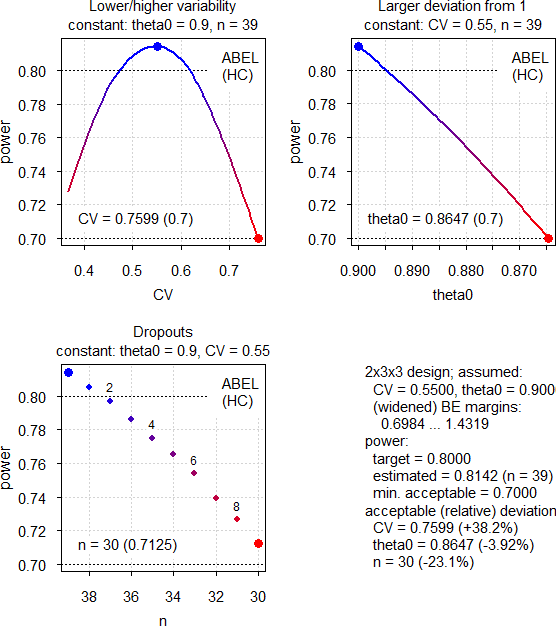

**Fig. 4** Power Analysis (in each panel one argument is varied and others kept constant)

Since we are close to Health Canada’s upper cap of 57.4%, power decreases on both sides. Note that three subjects less than for the EMA’s method are required and *CV*<sub>wR</sub> can increase to ~0.76 until we reach the minimum acceptable power – which is substantially higher than the ~0.67 for the EMA.

#### Gulf Cooperation Council

##### Example 5

Same assumptions (*CV*, $\small{\theta_0}$) like in Example 2 and Example 4.

```r
pa.scABE(CV = 0.55, regulator = "GCC")
# Sample size plan scABE (GCC/ABEL)
#  Design alpha CVwT CVwR theta0 theta1 theta2 Sample size Achieved power
#   2x3x3  0.05 0.55 0.55    0.9    0.8   1.25          75        0.80214
#  Target power
#           0.8
#
# Power analysis
# CV, theta0 and number of subjects leading to min. acceptable power of ~0.7:
#  CV= 0.6473, theta0= 0.8786
#  n = 57 (power= 0.7018)
```

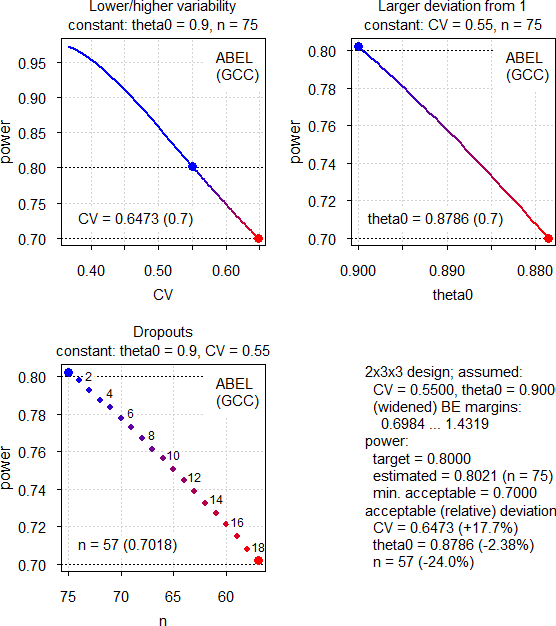

**Fig. 5** Power Analysis (in each panel one argument is varied and others kept constant)

#### FDA, CDE

##### Example 6

Same assumptions (*CV*, $\small{\theta_0}$) like in Example 2, Example 4 and Example 5.

```r
pa.scABE(CV = 0.55, regulator = "FDA")
# Sample size plan scABE (FDA/RSABE)
#  Design alpha CVwT CVwR theta0 theta1 theta2 Sample size Achieved power
#   2x3x3  0.05 0.55 0.55    0.9    0.8   1.25          30        0.80034
#  Target power
#           0.8
#
# Power analysis
# CV, theta0 and number of subjects leading to min. acceptable power of ~0.7:
#  CV= 0.9713, theta0= 0.8652
#  n = 23 (power= 0.7001)
```

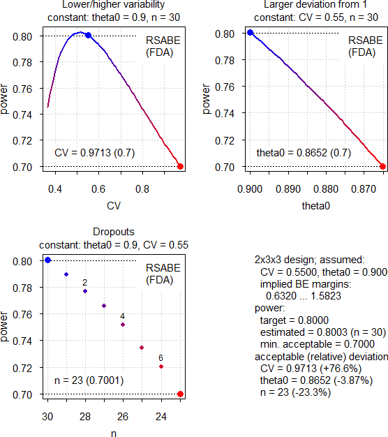

**Fig. 6** Power Analysis (in each panel one argument is varied and others kept constant)

A similar pattern like the one of Health Canada, although due to the different regulatory constants ($\small{\theta_s\approx0.8926}$ *vs* $\small{k=0.760}$ for Health Canada and the EMA) nine subjects less (and twelve less than for the EMA) are required. Due to unlimited scaling the *CV* can increase more.

### Narrow Therapeutic Index Drugs (FDA, CDE)

##### Example 7

Assumed intra-subject *CV* 0.125.

```r
pa.NTID(CV = 0.125)
# Sample size plan NTID
#  Design alpha  CVwT  CVwR theta0 theta1 theta2 Sample size Achieved power
#   2x2x4  0.05 0.125 0.125  0.975    0.8   1.25          16        0.82278
#  Target power
#           0.8
#
# Power analysis
# CV, theta0 and number of subjects leading to min. acceptable power of ~0.7:
#  CV = (0.0716, 0.3059), theta0= 0.9569
#  n = 13 (power= 0.7064)
```

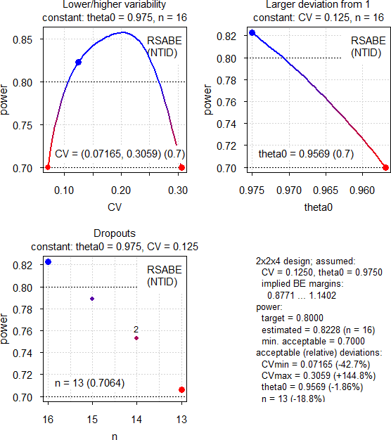

**Fig. 7** Power Analysis (in each panel one argument is varied and others kept constant)

With decreasing variability power decreases because the scaled limits become narrower. With increasing variability we gain power because we have to scale less until at ~21.4% the additional criterion “must pass conventional BE limits of 80.00–125.00%” cuts in.

# Cave!

The power analysis is not a substitute for the ‘Sensitivity Analysis’ recommended by the ICH.[^3] In a real study a combination of all effects occurs simultaneously. It is up to *you* to decide on reasonable combinations and analyze their respective power.

# Authors

| function | author(s) |
| --- | --- |
| `pa.ABE`, `pa.scABE` | Idea and original code by Helmut Schütz with modifications by Detlew Labes |
| `pa.NTID` | Detlew Labes acc. to code by Helmut Schütz for `pa.ABE` and `pa.scABE` |

# License

GPL-3 2024-03-18 Helmut Schütz

[^1]: Wickham H. *Advanced R.* 2019-08-08. [The S3 object system](http://adv-r.had.co.nz/S3.html).
[^2]: Tóthfalusi L, Endrényi L. *Sample Sizes for Designing Bioequivalence Studies for Highly Variable Drugs.* J Pharm Pharmaceut Sci. 2011;15(1):73–84. [Open access](http://ejournals.library.ualberta.ca/index.php/JPPS/article/download/11612/9489).
[^3]: International Conference on Harmonisation of Technical Requirements for Registration of Pharmaceuticals for Human Use. *ICH Harmonised Tripartite Guideline. Statistical Principles for Clinical Trials.* 5 February 1998. [E9 Step 4](https://database.ich.org/sites/default/files/E9_Guideline.pdf).